# DATA607TV1

Samantha Mesa

2026-11-17

## Introduction

This vignette demonstrates the use of core Tidyverse packages on a real dataset: readr to import the CSV, dplyr for data processing and summarization (mutate(), case_when(), group_by(), summarise(), across(), arrange(), slice_max(), count()), tidyr to reshape it with pivot_longer(), and ggplot2 to visualize the results. It uses Kaggle’s Social Media Usage Dataset, which includes 1,000 users, the app each user uses, and their daily minutes, posts, likes, and follows. with the question of which apps get the most engagement and whether more time spent equals more activity.

## 1. Load packages and data

```r
library(tidyverse)

social <- read_csv("https://raw.githubusercontent.com/Sampro24/DATA607Homeworks/main/social_media_usage.csv")

glimpse(social)
```

```
## Rows: 1,000
## Columns: 6
## $ User_ID             <chr> "U_1", "U_2", "U_3", "U_4", "U_5", "U_6", "U_7", "…
## $ App                 <chr> "Pinterest", "Facebook", "Instagram", "TikTok", "L…
## $ Daily_Minutes_Spent <dbl> 288, 192, 351, 21, 241, 464, 229, 8, 80, 428, 52, …
## $ Posts_Per_Day       <dbl> 16, 14, 13, 20, 16, 3, 1, 19, 7, 6, 18, 18, 17, 0,…
## $ Likes_Per_Day       <dbl> 94, 117, 120, 117, 9, 137, 188, 179, 14, 4, 124, 1…
## $ Follows_Per_Day     <dbl> 0, 15, 48, 8, 21, 30, 25, 48, 25, 41, 26, 28, 18, …
```

`glimpse()` gives a compact view of every column and its type.

## 2. Check data quality

```r
# Missing values per column, using across() inside summarise()
social %>%
  summarise(across(everything(), ~ sum(is.na(.x))))
```

```
## # A tibble: 1 × 6
##   User_ID   App Daily_Minutes_Spent Posts_Per_Day Likes_Per_Day Follows_Per_Day
##     <int> <int>               <int>         <int>         <int>           <int>
## 1       0     0                   0             0             0               0
```

```r
# Duplicate user IDs?
social %>% count(User_ID) %>% filter(n > 1)
```

```
## # A tibble: 0 × 2
## # ℹ 2 variables: User_ID <chr>, n <int>
```

```r
# Quick numeric summary
social %>%
  select(where(is.numeric)) %>%
  summary()
```

```
##  Daily_Minutes_Spent Posts_Per_Day   Likes_Per_Day    Follows_Per_Day
##  Min.   :  5.0       Min.   : 0.00   Min.   :  0.00   Min.   : 0.0
##  1st Qu.:112.8       1st Qu.: 5.00   1st Qu.: 44.75   1st Qu.:12.0
##  Median :246.0       Median :10.00   Median : 94.00   Median :24.0
##  Mean   :247.4       Mean   :10.27   Mean   : 94.68   Mean   :24.7
##  3rd Qu.:380.5       3rd Qu.:16.00   3rd Qu.:142.00   3rd Qu.:38.0
##  Max.   :500.0       Max.   :20.00   Max.   :200.00   Max.   :50.0
```

## 3. Summarize by app with `group_by()` and `summarise()`

```r
app_summary <- social %>%
  group_by(App) %>%
  summarise(
    users          = n(),
    avg_minutes    = mean(Daily_Minutes_Spent),
    avg_posts      = mean(Posts_Per_Day),
    avg_likes      = mean(Likes_Per_Day),
    avg_follows    = mean(Follows_Per_Day),
    .groups = "drop"
  ) %>%
  arrange(desc(avg_minutes))

app_summary
```

```
## # A tibble: 7 × 6
##   App       users avg_minutes avg_posts avg_likes avg_follows
##   <chr>     <int>       <dbl>     <dbl>     <dbl>       <dbl>
## 1 Instagram   140        264.     11.3       99.0        25.9
## 2 Twitter     140        258.     10.7       90.2        23.9
## 3 Snapchat    156        257.     10         93.8        25.5
## 4 Facebook    136        247.      9.52      99.3        23.1
## 5 Pinterest   140        236.     10.6       92.1        24.8
## 6 LinkedIn    147        236.     10.2       97.1        25.1
## 7 TikTok      141        233.      9.56      91.4        24.4
```

Use `across()` to apply the same summary to several columns at once:

```r
social %>%
  group_by(App) %>%
  summarise(across(c(Daily_Minutes_Spent, Posts_Per_Day, Likes_Per_Day, Follows_Per_Day),
                   list(mean = mean, sd = sd),
                   .names = "{.col}_{.fn}")) %>%
  mutate(across(where(is.numeric), ~ round(.x, 1)))
```

```
## # A tibble: 7 × 9
##   App       Daily_Minutes_Spent_mean Daily_Minutes_Spent_sd Posts_Per_Day_mean
##   <chr>                        <dbl>                  <dbl>              <dbl>
## 1 Facebook                      247.                   154.                9.5
## 2 Instagram                     264.                   151.               11.3
## 3 LinkedIn                      236.                   137.               10.2
## 4 Pinterest                     236.                   145.               10.6
## 5 Snapchat                      257.                   146.               10
## 6 TikTok                        233.                   145.                9.6
## 7 Twitter                       258.                   147.               10.7
## # ℹ 5 more variables: Posts_Per_Day_sd <dbl>, Likes_Per_Day_mean <dbl>,
## #   Likes_Per_Day_sd <dbl>, Follows_Per_Day_mean <dbl>,
## #   Follows_Per_Day_sd <dbl>
```

## 4. Create new variables with `mutate()` and `case_when()`

We build a total-activity measure and bucket users by time spent.

```r
social <- social %>%
  mutate(
    total_activity = Posts_Per_Day + Likes_Per_Day + Follows_Per_Day,
    usage_level = case_when(
      Daily_Minutes_Spent < 60  ~ "Light (<1 hr)",
      Daily_Minutes_Spent < 180 ~ "Moderate (1-3 hrs)",
      TRUE                      ~ "Heavy (3+ hrs)"
    ),
    usage_level = factor(usage_level,
                         levels = c("Light (<1 hr)", "Moderate (1-3 hrs)", "Heavy (3+ hrs)"))
  )

social %>% count(usage_level)
```

```
## # A tibble: 3 × 2
##   usage_level            n
##   <fct>              <int>
## 1 Light (<1 hr)        127
## 2 Moderate (1-3 hrs)   243
## 3 Heavy (3+ hrs)       630
```

Cross-tabulate app by usage level and compute proportions:

```r
social %>%
  count(App, usage_level) %>%
  group_by(App) %>%
  mutate(share = round(n / sum(n), 3)) %>%
  ungroup()
```

```
## # A tibble: 21 × 4
##    App       usage_level            n share
##    <chr>     <fct>              <int> <dbl>
##  1 Facebook  Light (<1 hr)         15 0.11
##  2 Facebook  Moderate (1-3 hrs)    42 0.309
##  3 Facebook  Heavy (3+ hrs)        79 0.581
##  4 Instagram Light (<1 hr)         17 0.121
##  5 Instagram Moderate (1-3 hrs)    31 0.221
##  6 Instagram Heavy (3+ hrs)        92 0.657
##  7 LinkedIn  Light (<1 hr)         16 0.109
##  8 LinkedIn  Moderate (1-3 hrs)    35 0.238
##  9 LinkedIn  Heavy (3+ hrs)        96 0.653
## 10 Pinterest Light (<1 hr)         20 0.143
## # ℹ 11 more rows
```

## 5. Find top users with `slice_max()`

```r
# Top 3 most active users on each app
social %>%
  group_by(App) %>%
  slice_max(total_activity, n = 3, with_ties = FALSE) %>%
  ungroup() %>%
  select(App, User_ID, Daily_Minutes_Spent, total_activity)
```

```
## # A tibble: 21 × 4
##    App       User_ID Daily_Minutes_Spent total_activity
##    <chr>     <chr>                 <dbl>          <dbl>
##  1 Facebook  U_114                   498            267
##  2 Facebook  U_413                   127            240
##  3 Facebook  U_321                   440            237
##  4 Instagram U_283                     7            244
##  5 Instagram U_726                   313            243
##  6 Instagram U_306                   387            240
##  7 LinkedIn  U_715                   338            250
##  8 LinkedIn  U_8                       8            246
##  9 LinkedIn  U_518                   419            245
## 10 Pinterest U_547                    79            249
## # ℹ 11 more rows
```

## 6. Reshape with tidyr and visualize with ggplot2

### 6.1 Average minutes per app

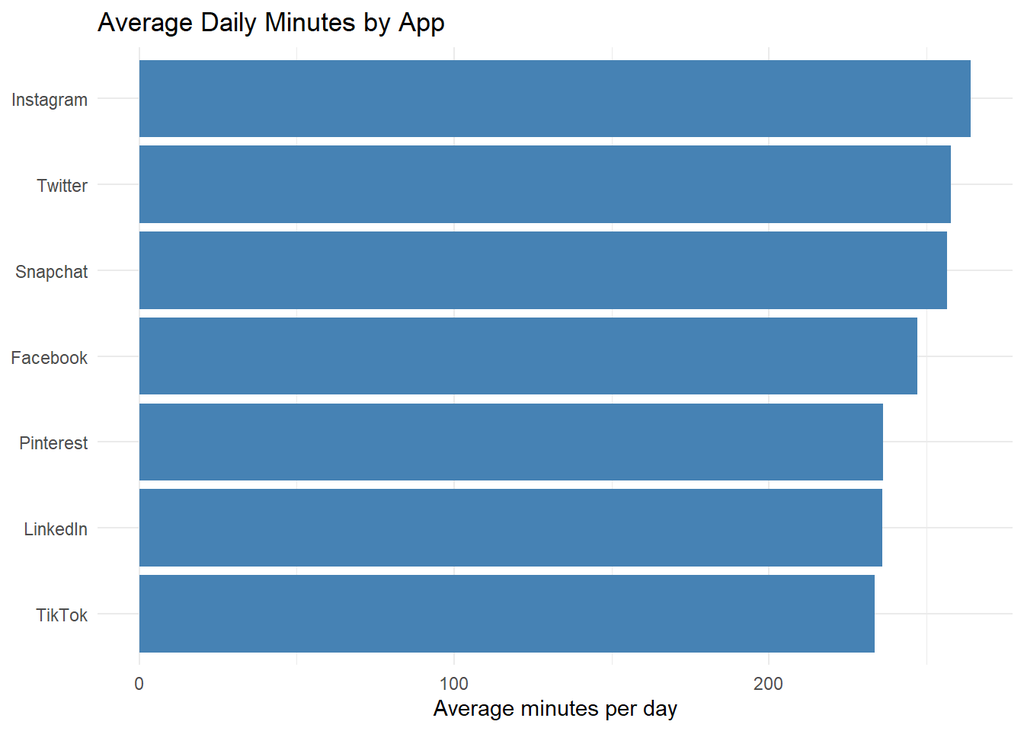

```r
app_summary %>%
  ggplot(aes(x = fct_reorder(App, avg_minutes), y = avg_minutes)) +
  geom_col(fill = "steelblue") +
  coord_flip() +
  labs(title = "Average Daily Minutes by App",
       x = NULL, y = "Average minutes per day") +
  theme_minimal()
```

### 6.2 Compare engagement types across apps

`pivot_longer()` turns the wide activity columns into a long format, which is what ggplot2 prefers for faceting and grouping.

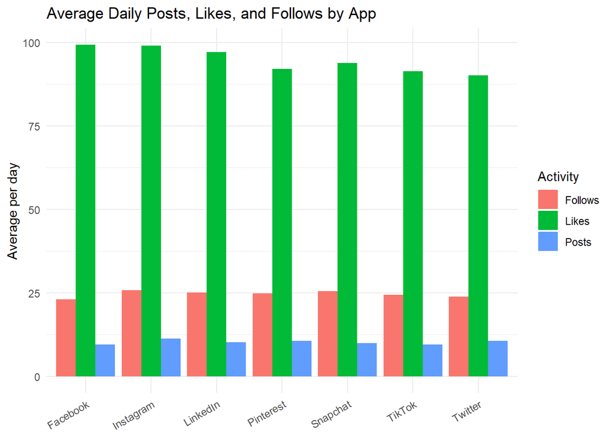

```r
activity_long <- social %>%
  pivot_longer(cols = c(Posts_Per_Day, Likes_Per_Day, Follows_Per_Day),
               names_to = "activity_type",
               values_to = "count") %>%
  mutate(activity_type = str_remove(activity_type, "_Per_Day"))

activity_long %>%
  group_by(App, activity_type) %>%
  summarise(avg_count = mean(count), .groups = "drop") %>%
  ggplot(aes(x = App, y = avg_count, fill = activity_type)) +
  geom_col(position = "dodge") +
  labs(title = "Average Daily Posts, Likes, and Follows by App",
       x = NULL, y = "Average per day", fill = "Activity") +
  theme_minimal() +
  theme(axis.text.x = element_text(angle = 30, hjust = 1))
```

### 6.3 Does more time mean more activity?

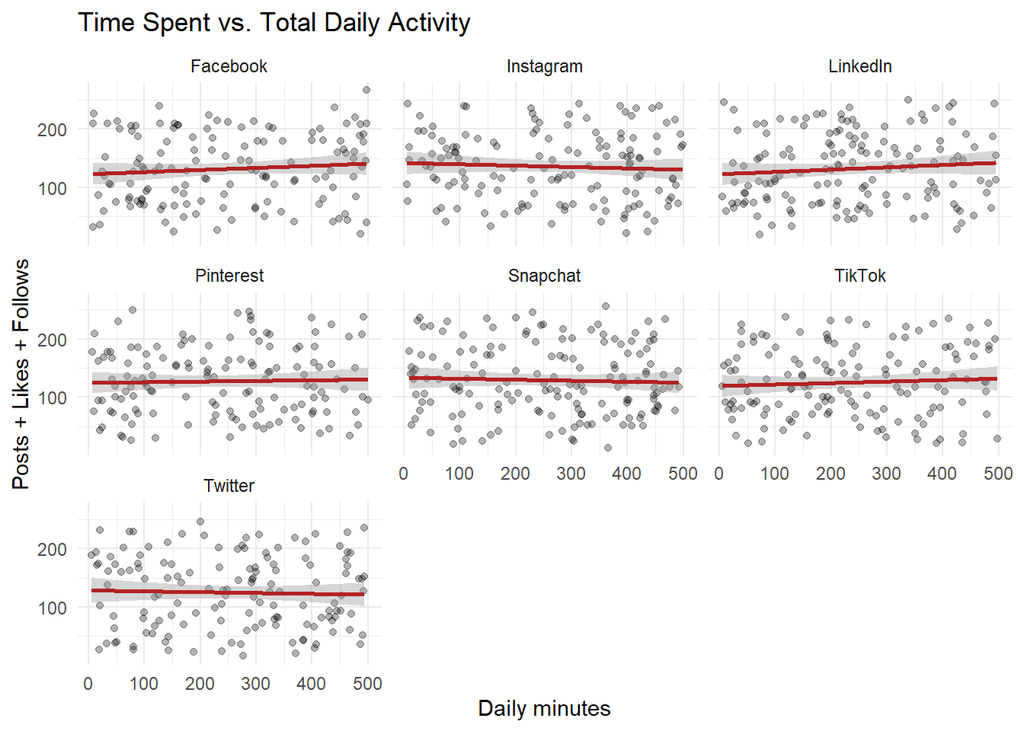

```r
ggplot(social, aes(x = Daily_Minutes_Spent, y = total_activity)) +
  geom_point(alpha = 0.3) +
  geom_smooth(method = "lm", se = TRUE, color = "firebrick") +
  facet_wrap(~ App) +
  labs(title = "Time Spent vs. Total Daily Activity",
       x = "Daily minutes", y = "Posts + Likes + Follows") +
  theme_minimal()
```

```r
# Correlation by app
social %>%
  group_by(App) %>%
  summarise(correlation = round(cor(Daily_Minutes_Spent, total_activity), 3),
            .groups = "drop") %>%
  arrange(desc(abs(correlation)))
```

```
## # A tibble: 7 × 2
##   App       correlation
##   <chr>           <dbl>
## 1 Facebook        0.092
## 2 LinkedIn        0.09
## 3 TikTok          0.063
## 4 Instagram      -0.06
## 5 Snapchat       -0.041
## 6 Twitter        -0.034
## 7 Pinterest       0.029
```

### 6.4 Distribution of time spent

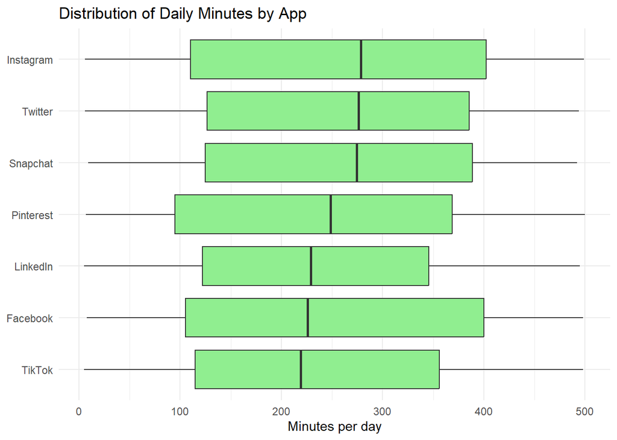

```r
ggplot(social, aes(x = fct_reorder(App, Daily_Minutes_Spent, .fun = median),
                   y = Daily_Minutes_Spent)) +
  geom_boxplot(fill = "lightgreen") +
  coord_flip() +
  labs(title = "Distribution of Daily Minutes by App", x = NULL, y = "Minutes per day") +
  theme_minimal()
```

## 7. Conclusion

This vignette showed how a few Tidyverse functions can take a dataset from import to insight in a single, readable pipeline. In terms of engagement, Instagram had the highest average daily time (around 264 minutes) and most posts and follows per day, but the differences between apps were small . Average daily minutes varied only from around 233 (TikTok) to 264 (Instagram), which is small compared with the approximately 150-minute standard deviation within each app. More time didn’t mean more activity either: the correlation between daily minutes and total activity was close to zero for each app (between roughly -0.06 and 0.09). Overall, it seems the app a person uses matters far less than the user themselves, and the lack of any real pattern suggests this dataset may be synthetic.

Using only a handful of TidyVerse functions, we show imported, cleaned, summarized, reshaped, and visualized the data in a readable pipeline:

- `group_by()` + `summarise()` quickly compared apps on average time and engagement.
- `mutate()` + `case_when()` created a total-activity measure and usage-level categories.
- `slice_max()` surfaced the most active users per app.
- `pivot_longer()` made it easy to plot several engagement metrics at once.
- `ggplot2` turned the results into clear comparisons.

## References

- Dataset: Bhadra Mohit, *Social Media Usage Dataset*, Kaggle.
- Data copy used for reproducibility: [GitHub repository](https://github.com/Sampro24/DATA607Homeworks/blob/main/social_media_usage.csv)